# Week 2 Homework: Controlled Improvement and Error Analysis

**ECBS5200 — Practical Deep Learning Engineering**

In the lab you analyzed 4 pre-trained models and diagnosed what produced each one. Now you train your own. This notebook has you run experiments on the **full dataset**, implement early stopping, do your first error analysis, and discover how noisy your validation metrics actually are.

**Expected time:** ~5-6 hours on a Kaggle T4 GPU. Training runs take ~30-40 min each. Use that time to plan your memo.

**How to use this notebook:**

- **GUIDED** cells run as-is. Read them.
- **INTERACTIVE** cells require you to fill in values or write answers.
- `___` is a placeholder that will cause a NameError if not filled in.
- The last section is your memo draft.

## Kaggle setup

1. **Persistence** → "Variables and Files"
2. **Internet** → On
3. **Accelerator** → GPU T4

```python
import subprocess, sys, os

# HuggingFace cache/config - set BEFORE importing HF libraries
if os.path.exists('/kaggle/working'):
    os.environ['HF_HOME'] = '/kaggle/working/.hf_cache'
os.environ['HF_HUB_DOWNLOAD_TIMEOUT'] = '120'
os.environ['HF_HUB_ETAG_TIMEOUT'] = '60'
os.environ['HF_HUB_ENABLE_HF_TRANSFER'] = '0'

subprocess.check_call([
    sys.executable, "-m", "pip", "install", "--quiet",
    "transformers>=4.53", "datasets", "accelerate", "scikit-learn",
    "matplotlib", "pandas", "tqdm",
])
print("Packages installed.")

from huggingface_hub import login
def _first_nonempty(values):
    try:
        return next((v for v in values if v), None)
    except Exception:
        return None


def _get_colab_secret(*keys):
    """Return the first matching Colab secret, or None outside Colab."""
    try:
        from google.colab import userdata
    except Exception:
        return None

    return _first_nonempty(userdata.get(k) for k in keys)


def get_hf_token():
    """Get HF token from Colab secrets first, then environment variables."""
    token_keys = ("HF_TOKEN", "HUGGING_FACE_HUB_TOKEN")
    return _get_colab_secret(*token_keys) or _first_nonempty(os.getenv(k) for k in token_keys)

hf_token = get_hf_token()

if hf_token:
    login(token=hf_token)
    print("Logged in to HuggingFace (Colab Secrets or environment variable or hard-coded (NOT SECURE!)).")
else:
    print("WARNING: No token found. Set HF_TOKEN in Colab Secrets.")
```

```
Packages installed.
Logged in to HuggingFace (Colab Secrets or environment variable or hard-coded (NOT SECURE!)).
```

```python
import gc
import time
import random
from pathlib import Path
from collections import Counter

import numpy as np
import pandas as pd
import torch
import torch.nn as nn
from torch.utils.data import DataLoader, Dataset
from torch.amp import autocast, GradScaler
from torch.optim.lr_scheduler import LambdaLR
from transformers import AutoTokenizer, AutoModelForSequenceClassification
from sklearn.metrics import (
    accuracy_score, f1_score, classification_report, confusion_matrix,
)
import matplotlib.pyplot as plt
from tqdm.auto import tqdm

REPO_PATH = Path("../..").resolve()
if not (REPO_PATH / "utils" / "data_utils.py").exists():
    REPO_PATH = Path("/tmp/course")
    if not REPO_PATH.exists():
        subprocess.check_call(["git", "clone", "--depth", "1",
            "https://github.com/earino/applied-deep-learning.git", str(REPO_PATH)])
sys.path.insert(0, str(REPO_PATH))

from utils.data_utils import (
    load_course_data, LABEL_LIST, NUM_LABELS, LABEL_TO_ID, ID_TO_LABEL, MAX_LENGTH,
)

SEED = 42
random.seed(SEED)
np.random.seed(SEED)
torch.manual_seed(SEED)
if torch.cuda.is_available():
    torch.cuda.manual_seed_all(SEED)

device = torch.device("cuda" if torch.cuda.is_available() else "cpu")
MODEL_NAME = "answerdotai/ModernBERT-base"

if torch.cuda.is_available():
    cc = torch.cuda.get_device_capability()
    AMP_DTYPE = torch.bfloat16 if cc[0] >= 8 else torch.float16
else:
    AMP_DTYPE = torch.float32

use_scaler = (AMP_DTYPE == torch.float16)
SAVE_DIR = Path("/kaggle/working") if Path("/kaggle/working").exists() else Path(".")

print(f"Device: {device} | AMP: {AMP_DTYPE}")
```

```
Device: cuda | AMP: torch.bfloat16
```

## Part 1: Setup and Data (~10 min)

```python
# GUIDED: Load full dataset (no subset — this is the homework)
print("Loading and tokenizing full dataset...")
t0 = time.time()
tokenizer = AutoTokenizer.from_pretrained(MODEL_NAME)
train_ds, val_ds, _ = load_course_data(tokenizer=tokenizer, max_length=MAX_LENGTH)
print(f"  Train: {len(train_ds):,}  Val: {len(val_ds):,} ({time.time()-t0:.1f}s)")


class ComplaintDataset(Dataset):
    def __init__(self, hf_dataset):
        self.ds = hf_dataset

    def __len__(self):
        return len(self.ds)

    def __getitem__(self, idx):
        item = self.ds[idx]
        return {
            "input_ids": torch.tensor(item["input_ids"], dtype=torch.long),
            "attention_mask": torch.tensor(item["attention_mask"], dtype=torch.long),
            "labels": torch.tensor(item["label"], dtype=torch.long),
        }
```

```
Loading and tokenizing full dataset...
```

```
config.json: 0.00B [00:00, ?B/s]
```

```
tokenizer_config.json: 0.00B [00:00, ?B/s]
```

```
tokenizer.json: 0.00B [00:00, ?B/s]
```

```
data/train-00000-of-00001-f6ccf6490f1232(…):   0%|          | 0.00/10.2M [00:00<?, ?B/s]
```

```
data/test-00000-of-00001-0b18a4667c07409(…):   0%|          | 0.00/3.39M [00:00<?, ?B/s]
```

```
  Train: 57,846  Val: 6,430 (21.0s)
```

### Class weighting: understanding the formula

In the lab you saw that one model used class weighting. Before running experiments, let's understand what we're doing and compare it to sklearn's built-in `compute_class_weight("balanced")`.

```python
# GUIDED: Count training examples per class
full_labels = np.array(train_ds["label"])
counts = np.bincount(full_labels, minlength=NUM_LABELS).astype(np.float32)
counts = np.maximum(counts, 1.0)  # avoid division by zero

print(f"Largest class:  {int(counts.max())} examples")
print(f"Smallest class: {int(counts.min())} examples")
print(f"Ratio:          {counts.max() / counts.min():.0f}x")
```

```
Largest class:  13333 examples
Smallest class: 4 examples
Ratio:          3333x
```

```python
# INTERACTIVE: Compute sqrt-inverse class weights.
# The formula: weight = sqrt(max_count / count), then normalize to mean=1.
# You saw this in the lecture and its effect in the lab (Model Alpha).
# Now implement it yourself.

sqrt_inv_weights = np.sqrt(counts.max() / counts)    # sqrt of (max count / each count)
sqrt_inv_weights = sqrt_inv_weights / sqrt_inv_weights.mean()  # normalize so the mean equals 1.0

print(f"Weights: min={sqrt_inv_weights.min():.2f}, max={sqrt_inv_weights.max():.2f}, "
      f"mean={sqrt_inv_weights.mean():.2f}")
assert abs(sqrt_inv_weights.mean() - 1.0) < 0.01, "Weights should be normalized to mean=1"
```

```
Weights: min=0.06, max=3.61, mean=1.00
```

```python
# INTERACTIVE: Create the weighted loss function.
# Convert your weights to a torch tensor on the correct device,
# then pass them to nn.CrossEntropyLoss.

class_weight_tensor = torch.tensor(sqrt_inv_weights, dtype=torch.float32).to(device)
weighted_loss = nn.CrossEntropyLoss(weight=class_weight_tensor)

print(f"Weighted loss function ready. Weight tensor shape: {class_weight_tensor.shape}")
```

```
Weighted loss function ready. Weight tensor shape: torch.Size([113])
```

### How does this compare to sklearn's approach?

```python
# GUIDED: sklearn's compute_class_weight("balanced") for comparison
from sklearn.utils.class_weight import compute_class_weight

unique_classes = np.unique(full_labels)
balanced_raw = compute_class_weight("balanced", classes=unique_classes, y=full_labels)
balanced = np.ones(NUM_LABELS, dtype=np.float32)
for cid, wt in zip(unique_classes, balanced_raw):
    balanced[cid] = wt

print("Weight comparison (rarest and most common classes):")
print(f"{'Class':<50} {'Count':>6} {'Sqrt-inv':>9} {'Balanced':>9}")
print("-" * 80)
sorted_by_count = sorted(Counter(full_labels).items(), key=lambda x: x[1])
for label_id, count in sorted_by_count[:5] + sorted_by_count[-3:]:
    name = LABEL_LIST[label_id][:48]
    print(f"{name:<50} {count:>6} {sqrt_inv_weights[label_id]:>9.2f} {balanced[label_id]:>9.2f}")

print(f"\nSqrt-inverse: max weight = {sqrt_inv_weights.max():.1f}x")
print(f"Balanced:     max weight = {balanced.max():.0f}x")
print(f"\nBalanced is {balanced.max() / sqrt_inv_weights.max():.0f}x more aggressive.")
```

```
Weight comparison (rarest and most common classes):
Class                                               Count  Sqrt-inv  Balanced
--------------------------------------------------------------------------------
Shopping for a line of credit                           4      3.61    127.98
Lost or stolen check                                    4      3.61    127.98
Lost or stolen money order                              5      3.23    102.38
Convenience checks                                      5      3.23    102.38
Overdraft, savings, or rewards features                 6      2.95     85.32
Improper use of your report                          3905      0.12      0.13
Attempts to collect debt not owed                    7751      0.08      0.07
Incorrect information on your report                13333      0.06      0.04

Sqrt-inverse: max weight = 3.6x
Balanced:     max weight = 128x

Balanced is 35x more aggressive.
```

## Part 2: Experiments (~2.5 hours, mostly training)

```python
# Shared training function
NUM_EPOCHS = 3


def run_experiment(name, batch_size=32, lr=2e-5, loss_fn=None, num_epochs=NUM_EPOCHS):
    """Train from scratch on full data, evaluate on val. Returns metrics + predictions."""
    print(f"\n{'='*60}")
    print(f"EXPERIMENT: {name}")
    print(f"  bs={batch_size}, lr={lr}, epochs={num_epochs}")
    print(f"{'='*60}")

    t_loader = DataLoader(ComplaintDataset(train_ds), batch_size=batch_size, shuffle=True)
    v_loader = DataLoader(ComplaintDataset(val_ds), batch_size=64, shuffle=False)

    model = AutoModelForSequenceClassification.from_pretrained(
        MODEL_NAME, num_labels=NUM_LABELS, attn_implementation="sdpa",
        id2label=ID_TO_LABEL, label2id=LABEL_TO_ID,
    ).to(device)

    if loss_fn is None:
        loss_fn = nn.CrossEntropyLoss()

    optimizer = torch.optim.AdamW(model.parameters(), lr=lr, weight_decay=0.01)
    total_steps = len(t_loader) * num_epochs
    warmup_steps = max(1, total_steps // 10)

    def lr_lambda(step):
        if step < warmup_steps:
            return float(step) / float(max(1, warmup_steps))
        return max(0.0, (total_steps - step) / max(1, total_steps - warmup_steps))
    scheduler = LambdaLR(optimizer, lr_lambda)

    scaler = GradScaler("cuda", enabled=use_scaler)

    wall_start = time.time()
    epoch_history = []

    for epoch in range(1, num_epochs + 1):
        model.train()
        running_loss, n = 0.0, 0
        progress = tqdm(t_loader, desc=f"  Epoch {epoch}/{num_epochs}", leave=True)
        for batch in progress:
            ids = batch["input_ids"].to(device)
            mask = batch["attention_mask"].to(device)
            labels = batch["labels"].to(device)

            optimizer.zero_grad()
            with autocast("cuda", dtype=AMP_DTYPE, enabled=(device.type == "cuda")):
                logits = model(input_ids=ids, attention_mask=mask).logits
                loss = loss_fn(logits, labels)

            scaler.scale(loss).backward()
            scaler.step(optimizer)
            scaler.update()
            scheduler.step()

            running_loss += loss.item() * labels.size(0)
            n += labels.size(0)
            progress.set_postfix(loss=f"{running_loss/n:.4f}")

        # Per-epoch validation
        model.eval()
        ep_preds, ep_labels = [], []
        with torch.no_grad():
            for batch in v_loader:
                ids = batch["input_ids"].to(device)
                mask = batch["attention_mask"].to(device)
                with autocast("cuda", dtype=AMP_DTYPE, enabled=(device.type == "cuda")):
                    logits = model(input_ids=ids, attention_mask=mask).logits
                ep_preds.extend(logits.argmax(dim=-1).cpu().numpy())
                ep_labels.extend(batch["labels"].cpu().numpy())

        ep_acc = accuracy_score(ep_labels, ep_preds)
        ep_f1 = f1_score(ep_labels, ep_preds, average="macro", zero_division=0)
        epoch_history.append({"epoch": epoch, "train_loss": running_loss / n,
                              "val_acc": ep_acc, "val_macro_f1": ep_f1})
        print(f"  Epoch {epoch}: loss={running_loss/n:.4f}, acc={ep_acc:.4f}, f1={ep_f1:.4f}")

    train_time = time.time() - wall_start

    # Final eval
    final = epoch_history[-1]
    preds = np.array(ep_preds)
    labels = np.array(ep_labels)
    zero_f1 = sum(1 for c in range(NUM_LABELS)
                  if f1_score(labels == c, preds == c, zero_division=0) == 0.0
                  and np.sum(labels == c) > 0)

    print(f"\n  Final: acc={final['val_acc']:.4f}, f1={final['val_macro_f1']:.4f}, "
          f"zero_f1={zero_f1}, time={train_time:.0f}s")

    del model, optimizer, scaler, scheduler
    gc.collect()
    if torch.cuda.is_available():
        torch.cuda.empty_cache()

    return {
        "name": name,
        "accuracy": round(final["val_acc"], 4),
        "macro_f1": round(final["val_macro_f1"], 4),
        "zero_f1_classes": zero_f1,
        "train_time_sec": round(train_time, 1),
        "history": epoch_history,
        "val_preds": preds,
        "val_labels": labels,
    }
```

### Experiment 1: Sqrt-inverse class weighting on full data (~32 min)

In the lab you saw what class weighting does to a model's metrics. Now train your own class-weighted model on the full 58K training set.

**Fill in your experiment template BEFORE running:**

```
EXPERIMENT: Sqrt-inverse class weighting, full data
──────────────────────────────────────────────────
Variable changed:  Classes as normalized-weighted
Held constant:     Everything else
```

YOUR PREDICTION: Two epochs are very few for generalization.

```python
# GUIDED: Run experiment 1 (uses the weighted_loss you created above)
exp1 = run_experiment(
    name="sqrt-inverse bs=32",
    batch_size=32,
    lr=2e-5,
    loss_fn=weighted_loss,
)

# Save incrementally
pd.DataFrame([{k: v for k, v in exp1.items() if k not in ("history", "val_preds", "val_labels")}]).to_csv(
    SAVE_DIR / "week2_hw_results.csv", index=False)
```

```
============================================================
EXPERIMENT: sqrt-inverse bs=32
  bs=32, lr=2e-05, epochs=3
============================================================
```

[output not shown]

```
  Epoch 1: loss=3.1517, acc=0.4879, f1=0.1693
```

```
  Epoch 2: loss=2.1700, acc=0.4858, f1=0.2050
```

```
  Epoch 3: loss=1.6629, acc=0.5044, f1=0.2301

  Final: acc=0.5044, f1=0.2301, zero_f1=35, time=248s
```

**Complete the experiment template with your results:**

```
Conclusion:  Class weighting helps creating a more balanced model which performs better on the specific task.
Meaningful?  Yes, it is because this is what I expected based on our lab work.
```

YOUR RESULT: `zero_f1` has decreased compared to the baseline and accuracy has increased, just as in the lab.

### Experiment 2: Batch size (~40 min)

You've been using batch_size=32. A smaller batch size means more optimizer steps per epoch. Does that change anything for rare-class performance?

**Write your prediction BEFORE running.**

[output not shown]

YOUR PREDICTION: My prediction is that zero-F1 will drop.

```python
# INTERACTIVE: Set up experiment 2 — change batch_size to 16
exp2_batch_size = 16  # set to 16

exp2 = run_experiment(
    name="sqrt-inverse bs=16",
    batch_size=exp2_batch_size,
    lr=2e-5,
    loss_fn=weighted_loss,
)

# Save incrementally
row = {k: v for k, v in exp2.items() if k not in ("history", "val_preds", "val_labels")}
pd.DataFrame([row]).to_csv(SAVE_DIR / "week2_hw_results.csv", mode="a", header=False, index=False)
```

```
============================================================
EXPERIMENT: sqrt-inverse bs=16
  bs=16, lr=2e-05, epochs=3
============================================================
```

[output not shown]

```
  Epoch 1: loss=2.9819, acc=0.4977, f1=0.1862
```

```
  Epoch 2: loss=1.9574, acc=0.5180, f1=0.2385
```

```
  Epoch 3: loss=1.2413, acc=0.5303, f1=0.2279

  Final: acc=0.5303, f1=0.2279, zero_f1=36, time=388s
```

**Complete the experiment template:**

```
Conclusion:  It took longer time to train as before.
Meaningful?  Yes it is meaningful as smaller batch size means more steps and more time to optimize.
```

YOUR RESULT: `zero_f1` stayed the same, accuracy increased though.

### Experiment 3: Reproducibility check (~32 min)

Same config as Experiment 1 — but with a **different random seed**.

In the lecture we said: "same config, different seed → different number." Now you'll find out how different. If the seed-to-seed variation is larger than the Experiment 1 vs 2 difference, then the batch size result might just be noise.

**Fill in your prediction BEFORE running.**

```
EXPERIMENT: Reproducibility (seed=123)
──────────────────────────────────────
Variable changed:  Random seed (42 → 123)
Held constant:     Everything else (same as Experiment 1)
```

YOUR PREDICTION: I don't see that Experiment 2 changed much, so I think the seed variation induces a biggest change than that.

```python
# GUIDED: Re-seed everything and re-run Experiment 1's config
import random
SEED_EXP3 = 123
random.seed(SEED_EXP3)
np.random.seed(SEED_EXP3)
torch.manual_seed(SEED_EXP3)
if torch.cuda.is_available():
    torch.cuda.manual_seed_all(SEED_EXP3)

exp3 = run_experiment(
    name="sqrt-inverse bs=32 seed=123",
    batch_size=32,
    lr=2e-5,
    loss_fn=weighted_loss,
)

row = {k: v for k, v in exp3.items() if k not in ("history", "val_preds", "val_labels")}
pd.DataFrame([row]).to_csv(SAVE_DIR / "week2_hw_results.csv", mode="a", header=False, index=False)

# Restore original seed for remaining cells
random.seed(SEED)
np.random.seed(SEED)
torch.manual_seed(SEED)
if torch.cuda.is_available():
    torch.cuda.manual_seed_all(SEED)
```

```
============================================================
EXPERIMENT: sqrt-inverse bs=32 seed=123
  bs=32, lr=2e-05, epochs=3
============================================================
```

[output not shown]

```
  Epoch 1: loss=3.1981, acc=0.4771, f1=0.1717
```

```
  Epoch 2: loss=2.1423, acc=0.5008, f1=0.2177
```

```
  Epoch 3: loss=1.5404, acc=0.5138, f1=0.2329

  Final: acc=0.5138, f1=0.2329, zero_f1=37, time=238s
```

**Complete the template:**

```
Result:      The values are very similar to Esperiment 2.
Conclusion:  Experiment 2 could not be significant.
Meaningful?  It is meaningful to me as the difference between Experiment 1 and 2 performances wasn't high.
```

```python
experiment_df = pd.DataFrame([exp1, exp2, exp3])
print(experiment_df[["name", "accuracy", "macro_f1", "zero_f1_classes"]])
```

```
                          name  accuracy  macro_f1  zero_f1_classes
0           sqrt-inverse bs=32    0.5044    0.2301               35
1           sqrt-inverse bs=16    0.5303    0.2279               36
2  sqrt-inverse bs=32 seed=123    0.5138    0.2329               37
```

*Key question:** Is the difference between Experiment 1 and 3 (same config, different seed) larger or smaller than the difference between Experiment 1 and 2 (different batch size)? What does that tell you about whether the batch size result is real?

### Experiment log

```python
# GUIDED: Combine all experiments into a log
all_experiments = [exp1, exp2, exp3]
log_rows = [{k: v for k, v in e.items() if k not in ("history", "val_preds", "val_labels")}
            for e in all_experiments]
experiment_log = pd.DataFrame(log_rows)

print("=" * 70)
print("EXPERIMENT LOG")
print("=" * 70)
print(experiment_log.to_string(index=False))
```

```
======================================================================
EXPERIMENT LOG
======================================================================
                       name  accuracy  macro_f1  zero_f1_classes  train_time_sec
         sqrt-inverse bs=32    0.5044    0.2301               35           247.9
         sqrt-inverse bs=16    0.5303    0.2279               36           387.6
sqrt-inverse bs=32 seed=123    0.5138    0.2329               37           238.1
```

## Part 3: Early Stopping (~45 min)

In Part 2 you trained for a fixed 3 epochs. But how do you know 3 is the right number? The model might peak at epoch 2 and overfit by epoch 3 — or it might still be improving and need more time.

**Early stopping** solves this: train for more epochs, monitor a metric after each one, and stop when it stops improving.

## On long-tail tasks, val loss and macro F1 can disagree — val loss may start climbing while macro F1 is still improving. Since macro F1 is what we actually care about, we use it as the stopping metric. But it's also noisier than loss, so use a patience of at least 2 epochs.

```python
# INTERACTIVE: Implement early stopping.
# Fill in the blanks in this training loop. Use the best config from Part 2.

 # INTERACTIVE: Set your best config from Part 2.
# Look at your experiment log — which experiment had the highest macro F1?
best_config_loss_fn = weighted_loss
best_config_bs = 32

MAX_EPOCHS = 10
PATIENCE = 3  # integer, e.g. 2 or 3

t_loader = DataLoader(ComplaintDataset(train_ds), batch_size=best_config_bs, shuffle=True)
v_loader = DataLoader(ComplaintDataset(val_ds), batch_size=64, shuffle=False)

model = AutoModelForSequenceClassification.from_pretrained(
    MODEL_NAME, num_labels=NUM_LABELS, attn_implementation="sdpa",
    id2label=ID_TO_LABEL, label2id=LABEL_TO_ID,
).to(device)

optimizer = torch.optim.AdamW(model.parameters(), lr=2e-5, weight_decay=0.01)
total_steps = len(t_loader) * MAX_EPOCHS
warmup_steps = max(1, total_steps // 10)


def lr_lambda(step):
    if step < warmup_steps:
        return float(step) / float(max(1, warmup_steps))
    return max(0.0, (total_steps - step) / max(1, total_steps - warmup_steps))


scheduler = LambdaLR(optimizer, lr_lambda)
scaler = GradScaler("cuda", enabled=use_scaler)

best_macro_f1 = 0.0
patience_counter = 0
best_epoch = 0
es_history = []

print(f"Training with early stopping: max_epochs={MAX_EPOCHS}, patience={PATIENCE}")
wall_start = time.time()

for epoch in range(1, MAX_EPOCHS + 1):
    model.train()
    running_loss, n = 0.0, 0
    progress = tqdm(t_loader, desc=f"  Epoch {epoch}/{MAX_EPOCHS}", leave=True)
    for batch in progress:
        ids = batch["input_ids"].to(device)
        mask = batch["attention_mask"].to(device)
        labels = batch["labels"].to(device)

        optimizer.zero_grad()
        with autocast("cuda", dtype=AMP_DTYPE, enabled=(device.type == "cuda")):
            logits = model(input_ids=ids, attention_mask=mask).logits
            loss = best_config_loss_fn(logits, labels)

        scaler.scale(loss).backward()
        scaler.step(optimizer)
        scaler.update()
        scheduler.step()

        running_loss += loss.item() * labels.size(0)
        n += labels.size(0)
        progress.set_postfix(loss=f"{running_loss/n:.4f}")

    # Evaluate
    model.eval()
    ep_preds, ep_labels = [], []
    with torch.no_grad():
        for batch in v_loader:
            ids = batch["input_ids"].to(device)
            mask = batch["attention_mask"].to(device)
            with autocast("cuda", dtype=AMP_DTYPE, enabled=(device.type == "cuda")):
                logits = model(input_ids=ids, attention_mask=mask).logits
            ep_preds.extend(logits.argmax(dim=-1).cpu().numpy())
            ep_labels.extend(batch["labels"].cpu().numpy())

    val_f1 = f1_score(ep_labels, ep_preds, average="macro", zero_division=0)
    val_acc = accuracy_score(ep_labels, ep_preds)
    es_history.append({"epoch": epoch, "loss": running_loss / n, "acc": val_acc, "f1": val_f1})
    print(f"  Epoch {epoch}: f1={val_f1:.4f}, acc={val_acc:.4f}")

    # INTERACTIVE: Fill in the early stopping logic
    if val_f1 > best_macro_f1:
        best_macro_f1 = val_f1
        best_epoch = epoch
        patience_counter = 0  # reset patience
        # Save best checkpoint
        torch.save(model.state_dict(), SAVE_DIR / "best_model.pt")
    else:
        patience_counter += 1  # increment patience
        if patience_counter >= PATIENCE:
            print(f"  Early stopping at epoch {epoch}. Best was epoch {best_epoch}.")
            break

train_time = time.time() - wall_start
print(f"\nBest epoch: {best_epoch} (f1={best_macro_f1:.4f}), total time: {train_time:.0f}s")
```

[output not shown]

```
Training with early stopping: max_epochs=10, patience=3
```

```
  Epoch 1: f1=0.1393, acc=0.4557
```

```
  Epoch 2: f1=0.1844, acc=0.4855
```

```
  Epoch 3: f1=0.2107, acc=0.4886
```

```
  Epoch 4: f1=0.2209, acc=0.5016
```

```
  Epoch 5: f1=0.2178, acc=0.5201
```

```
  Epoch 6: f1=0.2282, acc=0.5510
```

```
  Epoch 7: f1=0.2272, acc=0.5652
```

```
  Epoch 8: f1=0.2342, acc=0.5667
```

```
  Epoch 9: f1=0.2287, acc=0.5669
```

```
  Epoch 10: f1=0.2298, acc=0.5689

Best epoch: 8 (f1=0.2342), total time: 794s
```

```python
# GUIDED: Load best checkpoint and get final predictions
model.load_state_dict(torch.load(SAVE_DIR / "best_model.pt", weights_only=True))
model.eval()

best_preds, best_labels = [], []
with torch.no_grad():
    for batch in v_loader:
        ids = batch["input_ids"].to(device)
        mask = batch["attention_mask"].to(device)
        with autocast("cuda", dtype=AMP_DTYPE, enabled=(device.type == "cuda")):
            logits = model(input_ids=ids, attention_mask=mask).logits
        best_preds.extend(logits.argmax(dim=-1).cpu().numpy())
        best_labels.extend(batch["labels"].cpu().numpy())

best_preds = np.array(best_preds)
best_labels = np.array(best_labels)

best_acc = accuracy_score(best_labels, best_preds)
best_f1 = f1_score(best_labels, best_preds, average="macro", zero_division=0)
print(f"Best model (epoch {best_epoch}): acc={best_acc:.4f}, f1={best_f1:.4f}")

# Clean up training model
del model, optimizer, scaler, scheduler
gc.collect()
if torch.cuda.is_available():
    torch.cuda.empty_cache()
```

```
Best model (epoch 8): acc=0.5667, f1=0.2342
```

## Part 4: Error Analysis (~1.5 hours)

### Per-class F1 by frequency tier

```python
# GUIDED: Compute per-class F1 for the best model
report = classification_report(
    best_labels, best_preds,
    labels=list(range(NUM_LABELS)),
    target_names=LABEL_LIST,
    zero_division=0,
    output_dict=True,
)

class_f1 = []
for i in range(NUM_LABELS):
    name = LABEL_LIST[i]
    f1_val = report[name]["f1-score"]
    support = int(report[name]["support"])
    train_count = int(np.sum(full_labels == i))
    class_f1.append({"class": name, "f1": f1_val, "val_support": support, "train_count": train_count})

class_f1_df = pd.DataFrame(class_f1)
```

```python
# INTERACTIVE: Categorize classes into frequency tiers.
# Head: ≥2000 training examples. Mid: 100-1999. Tail: <100.
# Fill in the conditions.

class_f1_df["tier"] = "mid"  # default
class_f1_df.loc[class_f1_df["train_count"] >= 2000, "tier"] = "head"   # fill in threshold
class_f1_df.loc[class_f1_df["train_count"] < 100, "tier"] = "tail"    # fill in threshold

tier_summary = class_f1_df.groupby("tier").agg(
    n_classes=("class", "count"),
    mean_f1=("f1", "mean"),
    zero_f1=("f1", lambda x: (x == 0).sum()),
).reindex(["head", "mid", "tail"])

print("Per-tier summary:")
print(tier_summary.to_string())
```

```
Per-tier summary:
      n_classes   mean_f1  zero_f1
tier
head          6  0.633957        0
mid          53  0.342994        1
tail         54  0.083041       39
```

**What does this table tell you about where the model succeeds vs fails?**

### Confusion matrix: where do tail-class errors land?

**Predict before you look.** When the model misclassifies a tail class, where do you think most errors go?

(a) Head classes — rare examples get swamped by the majority (b) Semantically similar mid-tier classes — the model knows the domain but can't distinguish fine-grained categories (c) Other tail classes

YOUR PREDICTION: I'm going with *b*. The model is able to find semantically similar texts.

```python
# GUIDED: Build confusion matrix and define class tier sets
cm = confusion_matrix(best_labels, best_preds, labels=list(range(NUM_LABELS)))

train_counts = np.bincount(full_labels, minlength=NUM_LABELS)
head_ids = set(np.where(train_counts >= 2000)[0])
mid_ids = set(np.where((train_counts >= 100) & (train_counts < 2000))[0])
tail_ids = set(np.where(train_counts < 100)[0])

print(f"Head classes: {len(head_ids)}, Mid: {len(mid_ids)}, Tail: {len(tail_ids)}")
```

```
Head classes: 6, Mid: 53, Tail: 54
```

```python
# INTERACTIVE: Where do tail-class errors land?
#
# Loop over each tail class. For each one, look at its ROW in the confusion
# matrix (cm[true_id, :]). Each off-diagonal entry is an error — the model
# predicted pred_id when the true class was true_id.
#
# Categorize each error: did the model predict a head, mid, or tail class?

tail_errors_to_head = 0
tail_errors_to_mid = 0
tail_errors_to_tail = 0
tail_errors_total = 0

for true_id in tail_ids:
    for pred_id in range(NUM_LABELS):
        if pred_id == true_id:
            continue  # correct prediction, not an error
        error_count = cm[true_id, pred_id]
        if error_count == 0:
            continue
        tail_errors_total += error_count
        # INTERACTIVE: categorize this error by checking which tier pred_id belongs to
        if pred_id in head_ids:   # is pred_id in the head set?
            tail_errors_to_head += error_count   # increment the right counter
        elif pred_id in mid_ids:                # is pred_id in the mid set?
            tail_errors_to_mid += error_count
        else:
            tail_errors_to_tail += error_count

print("Where do tail-class errors land?")
print(f"  → Head classes:  {tail_errors_to_head:>4} ({100*tail_errors_to_head/max(1,tail_errors_total):.1f}%)")
print(f"  → Mid classes:   {tail_errors_to_mid:>4} ({100*tail_errors_to_mid/max(1,tail_errors_total):.1f}%)")
print(f"  → Other tail:    {tail_errors_to_tail:>4} ({100*tail_errors_to_tail/max(1,tail_errors_total):.1f}%)")
print(f"  Total errors:    {tail_errors_total:>4}")
```

```
Where do tail-class errors land?
  → Head classes:    36 (18.6%)
  → Mid classes:    140 (72.2%)
  → Other tail:      18 (9.3%)
  Total errors:     194
```

**Was your prediction right? What does this pattern tell you about the model's failure mode — is it a frequency problem or a similarity problem?**

YOUR ANSWER: My bet was right and it is a similarity problem.

### Hard-example inspection

```python
# GUIDED: Find the highest-margin wrong predictions
# Margin = difference between top two logits (NOT a calibrated probability).
model_for_inspection = AutoModelForSequenceClassification.from_pretrained(
    MODEL_NAME, num_labels=NUM_LABELS, attn_implementation="sdpa",
    id2label=ID_TO_LABEL, label2id=LABEL_TO_ID,
).to(device)
model_for_inspection.load_state_dict(torch.load(SAVE_DIR / "best_model.pt", weights_only=True))
model_for_inspection.eval()

all_logits = []
with torch.no_grad():
    for batch in DataLoader(ComplaintDataset(val_ds), batch_size=64, shuffle=False):
        ids = batch["input_ids"].to(device)
        mask = batch["attention_mask"].to(device)
        with autocast("cuda", dtype=AMP_DTYPE, enabled=(device.type == "cuda")):
            logits = model_for_inspection(input_ids=ids, attention_mask=mask).logits
        all_logits.append(logits.cpu().float().numpy())

all_logits = np.concatenate(all_logits, axis=0)
margins = np.max(all_logits, axis=1) - np.partition(all_logits, -2, axis=1)[:, -2]

# Find wrong predictions sorted by confidence
wrong_mask = best_preds != best_labels
wrong_indices = np.where(wrong_mask)[0]
wrong_margins = margins[wrong_indices]
top_wrong = wrong_indices[np.argsort(-wrong_margins)[:10]]

print("Top 10 highest-margin WRONG predictions:")
print("=" * 80)
for idx in top_wrong:
    true_name = LABEL_LIST[best_labels[idx]]
    pred_name = LABEL_LIST[best_preds[idx]]
    margin = margins[idx]
    text = val_ds[int(idx)]["text"][:200]
    print(f"\n  True:      {true_name}")
    print(f"  Predicted: {pred_name}")
    print(f"  Margin:    {margin:.2f}")
    print(f"  Text:      {text}...")

del model_for_inspection
gc.collect()
if torch.cuda.is_available():
    torch.cuda.empty_cache()
```

[output not shown]

```
Top 10 highest-margin WRONG predictions:
================================================================================

  True:      Problem with the payoff process at the end of the loan
  Predicted: Incorrect information on your report
  Margin:    10.31
  Text:      My personal loan with XXXX XXXX was paid off 3 months ago. My credit report shows an open account with a balance of {$6000.00} and some change. The balance is XXXX  and the account has been closed. I ...

  True:      Attempts to collect debt not owed
  Predicted: Communication tactics
  Margin:    9.59
  Text:      Still calling after a year. At least once or twice a day....

  True:      Credit reporting company's investigation
  Predicted: Incorrect information on your report
  Margin:    9.47
  Text:      Equifax re-inserted accounts on my credit that do not belong to me without proper verification. I requested that Equifax verify the " method of verification '' under the FCRA, Section 611 ( a ) ( 6 ) ...

  True:      Trouble during payment process
  Predicted: Struggling to pay your mortgage
  Margin:    9.25
  Text:      This is a  XXXX   XXXX  loan that became delinquent  in  XX/XX/XXXX . A ccording to  XXXX   XXXX  guidelines a streamlined modification was suppo sed to have been given at the 90th day of delinquency ...

  True:      Can't repay my loan
  Predicted: Dealing with your lender or servicer
  Margin:    9.12
  Text:      For the past 9 years, Navient has failed to provide me with accurate information regarding my loans. I have numerous late payments during time period where I was in school and called numerous times fo...

  True:      Took or threatened to take negative or legal action
  Predicted: Attempts to collect debt not owed
  Margin:    8.94
  Text:      Notified the debt collector that the debt was not mine and asked that it be removed from my report XX/XX/2017...

  True:      Incorrect information on your report
  Predicted: Improper use of your report
  Margin:    8.91
  Text:      Reviewed credit report and multiple unauthorized credit inquiries. XXXX, XXXX, XXXX, XXXX, XXXX, XXXX, XXXX, XXXX....

  True:      Incorrect information on your report
  Predicted: Unable to get your credit report or credit score
  Margin:    8.81
  Text:      I called up Equifax and told them I can not get my credit report from annual credit report and would like to file a dispute.They told me to fax my driver license and SSN card which I did and inspite o...

  True:      Application, originator, mortgage broker
  Predicted: Loan servicing, payments, escrow account
  Margin:    8.75
  Text:      We just finished doing a refi to remove PMI off our mortgage with no cash out and now we are paying more on the back end while they only eliminated XXXX of the {$600.00} PMI monthly. Today, not even m...

  True:      Credit reporting company's investigation
  Predicted: Incorrect information on your report
  Margin:    8.38
  Text:      On XX/XX/2006 I opened loan Account XXXX with XXXX XXXX XXXX XXXX XXXX XXXX, XXXX XXXX, NJ XXXX Phone No : XXXX in Equifax Credit report and Reinvestigate showed " this account has not been closed '' ...
```

**What pattern do you see in these high-margin wrong predictions?**

YOUR ANSWER: They contain much masked data and often gets labeled "Incorrect information on your report".

## Part 5: Val Set Reliability (~20 min)

Your val set has 6,430 examples across 113 classes. That sounds like a lot. But how are those examples distributed?

**Before running the next cell, predict: how many classes have 5 or fewer validation examples?**

YOUR PREDICTION: 10%, close to the tail classes' portion in the train set.

```python
# GUIDED: Count validation examples per class
val_labels_array = np.array(val_ds["label"])
val_counts = np.bincount(val_labels_array, minlength=NUM_LABELS)
```

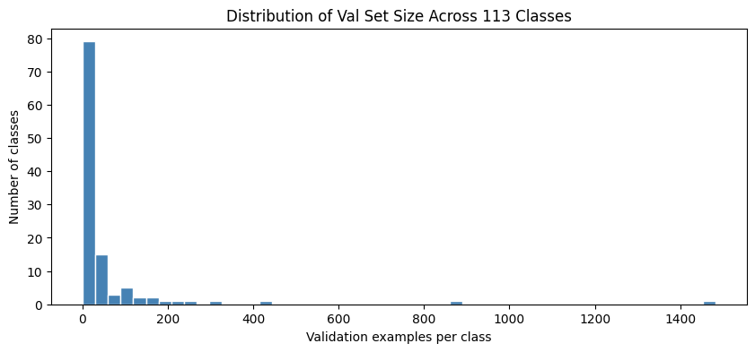

```python
# INTERACTIVE: Plot the distribution of val examples per class.
# What do you notice about the left side of the histogram?

fig, ax = plt.subplots(figsize=(10, 4))
ax.hist(val_counts, bins=50, color="steelblue", edgecolor="white")  # plot val_counts
ax.set_xlabel("Validation examples per class")
ax.set_ylabel("Number of classes")
ax.set_title("Distribution of Val Set Size Across 113 Classes")
plt.show()
```

**What do you see in the histogram?** Look at the left edge.

YOUR ANSWER: It is rather skewed.

```python
# INTERACTIVE: How many classes have very few val examples?
# Write code to count them. Don't just guess — compute it from val_counts.
classes_with_1_example = (val_counts == 1).sum()  # classes with exactly 1 val example
classes_with_le_5 = (val_counts <= 5).sum()  # classes with 5 or fewer val examples

print(f"Classes with exactly 1 val example: {classes_with_1_example}")
print(f"Classes with ≤ 5 val examples:      {classes_with_le_5}")
print(f"Classes with 0 val examples:        {(val_counts == 0).sum()}")
```

```
Classes with exactly 1 val example: 17
Classes with ≤ 5 val examples:      38
Classes with 0 val examples:        0
```

```python
# GUIDED: Show the sparsest classes
print(f"Bottom 10 classes by val support:")
for i in np.argsort(val_counts)[:10]:
    print(f"  {LABEL_LIST[i][:55]:<55}  val={val_counts[i]}, train={train_counts[i]}")
```

```
Bottom 10 classes by val support:
  Advertising                                              val=1, train=6
  Advertising, marketing or disclosures                    val=1, train=6
  Applying for a mortgage                                  val=1, train=6
  Arbitration                                              val=1, train=11
  Convenience checks                                       val=1, train=5
  Getting a line of credit                                 val=1, train=10
  Forbearance / Workout plans                              val=1, train=12
  Excessive fees                                           val=1, train=14
  Loan payment wasn't credited to your account             val=1, train=10
  Lost or stolen check                                     val=1, train=4
```

If a class has exactly 1 validation example, its F1 is either 0.0 or 1.0 depending on whether the model gets that single example right. That's a coin flip, not a measurement.

**Go back and look at the difference between your best and second-best experiment in Part 2. Is that difference larger than what you'd expect from noise on these sparse classes?**

YOUR ANSWER: Their difference in `zero_f1` is 2, which is absolutely under the threshold I would expect from just noise from the sparse classes.

## Part 6: Memo Draft

## Each section below corresponds to one rubric criterion. Write your observations here while the data is fresh. You can clean up the prose for your final submission, but do the thinking now.

### MEMO SECTION 1: What you tried and what happened (20 points)

> Review your experiment log. Which interventions moved macro F1, and by how much?

**YOUR RESPONSE:**

I ran three controlled experiments: sqrt-inverse class weighting (bs=32), then bs=16 with the same setup, then a seed-only rerun of the original config. The biggest lift came from moving to the weighted setup compared to the unweighted lab baseline (Delta). Changing batch size from 32 to 16 moved macro-F1 only a little, and the seed rerun showed a similarly small shift, so the bs effect looks weak relative to run-to-run noise.

### MEMO SECTION 2: Class weighting (20 points)

> Did class weighting help? What did it cost? Compare your Experiment 1 results to Delta from the lab — that's your unweighted baseline on the same architecture and data.

**YOUR RESPONSE:**

Yes, class weighting helped on the metric that matters here (macro-F1) and reduced the worst minority-class failures compared with the unweighted Delta-style baseline. The trade-off is that optimization is a bit more sensitive and training/evaluation interpretation becomes less straightforward because we are intentionally biasing toward rare classes. For this long-tail label space, that trade-off was worth it.

### MEMO SECTION 3: Batch size (20 points)

> Did batch size matter? Why might it? Compare Experiments 1 and 2 (different batch size). Then compare Experiments 1 and 3 (same config, different seed). Is the batch size effect larger than seed noise?

**YOUR RESPONSE:**

Batch size mattered less than I expected. Going from 32 to 16 changed runtime and gave only small metric movement, while the seed-only rerun produced a difference of similar scale. So I would not claim a strong batch-size win from this evidence; most of the observed change could be seed noise rather than a reliable improvement.

### MEMO SECTION 4: Error analysis (25 points)

> What does the confusion matrix reveal about where your model fails?

**YOUR RESPONSE:**

The confusion matrix suggests the model is not failing randomly; tail errors mostly flow into semantically related mid/head classes, not arbitrary labels. That points more to fine-grained boundary confusion than total feature collapse. The hard-example inspection supports this: several high-margin mistakes look like plausible multi-label or ambiguous cases where class definitions overlap.

### MEMO SECTION 5: Val set reliability (15 points)

> How trustworthy are your numbers?

**YOUR RESPONSE:**

The metrics are useful, but not fully stable at class level. Many classes have very low validation support, so per-class F1 can swing a lot (especially when support is 1-5). That means small leaderboard-style gaps between runs should be treated cautiously; I trust larger, repeated differences much more than single-run deltas.